# CH3 : Logistic Regression

TP4

> In this PW we are going to analyse the `Social_Network_Ads` dataset. This dataset contains informations of users of a social network. The social network has several business clients and its business clients put ads on the social network for marketing compaigns purposes. For this dataset, a company has put ads for one of its new products and the social network gathered some informations about wich users responded positively to the ad by buying the product and those who responded negatively by not buying the product.

# Question 1

Import the `Social_Network_Ads` dataset into `R`

```r
data = read.csv("Social_Network_Ads.csv")
data
```

```
##      User.ID Gender Age EstimatedSalary Purchased
## 1   15624510   Male  19           19000         0
## 2   15810944   Male  35           20000         0
## 3   15668575 Female  26           43000         0
## 4   15603246 Female  27           57000         0
## 5   15804002   Male  19           76000         0
## 6   15728773   Male  27           58000         0
## 7   15598044 Female  27           84000         0
## 8   15694829 Female  32          150000         1
## 9   15600575   Male  25           33000         0
## 10  15727311 Female  35           65000         0
## 11  15570769 Female  26           80000         0
## 12  15606274 Female  26           52000         0
## 13  15746139   Male  20           86000         0
## 14  15704987   Male  32           18000         0
```

[output cut: 386 more lines]

```r
View(data)
```

# Question 2

Describe the dataset (you can use `str()` and `summary()` functions).

```r
summary(data)
```

```
##     User.ID            Gender               Age        EstimatedSalary
##  Min.   :15566689   Length:400         Min.   :18.00   Min.   : 15000
##  1st Qu.:15626764   Class :character   1st Qu.:29.75   1st Qu.: 43000
##  Median :15694342   Mode  :character   Median :37.00   Median : 70000
##  Mean   :15691540                      Mean   :37.66   Mean   : 69743
##  3rd Qu.:15750363                      3rd Qu.:46.00   3rd Qu.: 88000
##  Max.   :15815236                      Max.   :60.00   Max.   :150000
##    Purchased
##  Min.   :0.0000
##  1st Qu.:0.0000
##  Median :0.0000
##  Mean   :0.3575
##  3rd Qu.:1.0000
##  Max.   :1.0000
```

```r
str(data)
```

```
## 'data.frame':    400 obs. of  5 variables:
##  $ User.ID        : int  15624510 15810944 15668575 15603246 15804002 15728773 15598044 15694829 15600575 15727311 ...
##  $ Gender         : chr  "Male" "Male" "Female" "Female" ...
##  $ Age            : num  19 35 26 27 19 27 27 32 25 35 ...
##  $ EstimatedSalary: num  19000 20000 43000 57000 76000 58000 84000 150000 33000 65000 ...
##  $ Purchased      : int  0 0 0 0 0 0 0 1 0 0 ...
```

> We will consider the variables Age and EstimatedSalary as input variables (features) to see the correlations between them and the decision of the user to buy (or not) the product

# Question 3

Now we are going to split the dataset into training set and test set. Last week we did it manually. From now on split it randomly with caTools packages

```r
library(caTools) # install it first in the console
set.seed(123) # we use this function with the same number to randomly generate the same values

sample = sample.split(data, SplitRatio = 0.75)
training  = subset(data, sample == TRUE)
testing   = subset(data, sample == FALSE)
```

# Question 4

Scale the input variables in both training set and test set.

```r
training$Age = scale(training$Age)
training$EstimatedSalary = scale(training$EstimatedSalary)
testing$Age = scale(testing$Age)
testing$EstimatedSalary = scale(testing$EstimatedSalary)

training
```

```
##      User.ID Gender         Age EstimatedSalary Purchased
## 1   15624510   Male -1.70308667     -1.52878620         0
## 2   15810944   Male -0.23312650     -1.49914181         0
## 3   15668575 Female -1.05997910     -0.81732070         0
## 6   15728773   Male -0.96810659     -0.37265476         0
## 7   15598044 Female -0.96810659      0.39809953         0
## 8   15694829 Female -0.50874403      2.35462966         1
## 11  15570769 Female -1.05997910      0.27952195         0
## 12  15606274 Female -1.05997910     -0.55052114         0
## 13  15746139   Male -1.61121416      0.45738833         0
## 16  15697686   Male -0.78436156      0.27952195         0
## 17  15733883   Male  0.86934364     -1.35091983         1
## 18  15617482   Male  0.68559861     -1.32127543         1
## 21  15649487   Male  0.68559861     -1.43985301         1
## 22  15736760 Female  0.86934364     -0.63945432         1
```

[output cut: 226 more lines]

```r
testing
```

```
##      User.ID Gender         Age EstimatedSalary Purchased
## 4   15603246 Female -1.09621842     -0.33136737         0
## 5   15804002   Male -1.90588926      0.21610916         0
## 9   15600575   Male -1.29863613     -1.02291667         0
## 10  15727311 Female -0.28654757     -0.10085094         0
## 14  15704987   Male -0.59017414     -1.45513499         0
## 15  15628972   Male -2.00709812      0.38899648         0
## 19  15704583   Male  0.82674984     -1.16698945         1
## 20  15621083 Female  1.02916755     -1.13817489         1
## 24  15599081 Female  0.72554098     -1.33987677         1
## 25  15705113   Male  0.82674984     -1.31106222         1
## 29  15744529   Male -0.89380071     -0.73477113         0
## 30  15669656   Male -0.69138300     -1.45513499         0
## 34  15776733 Female -0.99500956     -0.70595658         0
## 35  15724858   Male -1.09621842      0.61951292         0
```

[output cut: 146 more lines]

# Question 5

Fit a simple logistic regression model of `Purchased` in function of `Age`

```r
model = glm(Purchased~Age,family=binomial(link='logit'),data=training)
model
```

```
##
## Call:  glm(formula = Purchased ~ Age, family = binomial(link = "logit"),
##     data = training)
##
## Coefficients:
## (Intercept)          Age
##     -0.8964       2.0252
##
## Degrees of Freedom: 239 Total (i.e. Null);  238 Residual
## Null Deviance:       315.4
## Residual Deviance: 200.2     AIC: 204.2
```

```r
summary(model)
```

```
##
## Call:
## glm(formula = Purchased ~ Age, family = binomial(link = "logit"),
##     data = training)
##
## Deviance Residuals:
##     Min       1Q   Median       3Q      Max
## -2.5065  -0.6734  -0.2543   0.5669   2.4137
##
## Coefficients:
##             Estimate Std. Error z value Pr(>|z|)
## (Intercept)  -0.8964     0.1890  -4.742 2.12e-06 ***
## Age           2.0252     0.2630   7.701 1.35e-14 ***
## ---
## Signif. codes:  0 '***' 0.001 '**' 0.01 '*' 0.05 '.' 0.1 ' ' 1
##
## (Dispersion parameter for binomial family taken to be 1)
##
##     Null deviance: 315.44  on 239  degrees of freedom
## Residual deviance: 200.25  on 238  degrees of freedom
## AIC: 204.25
##
## Number of Fisher Scoring iterations: 5
```

# Question 6

In the argument `family` of the function `glm` we chose `binomial`. Why ?

```r
# Because purchase only takes values between 0 and 1
```

# Question 7

What is the equation of the obtained model in the question 1.5 ?

```r
# Fonction type : f(x,y) = ax + by
```

# Question 8

Is the feature `Age` significant?

```r
# Age is significative because p-value < 0.05
```

The `AIC` is the `Akaike Information Criterion`. You will use this while comparing multiple models. The model with lower value of `AIC` is better. Suppose that we have a statistical model of some data. Let $L$ be the maximum value of the likelihood function for the model; let `k` be the number of estimated parameters in the model. Then the `AIC` value of the model is the following.

$AIC=2k−2ln(L)$

where

- $L$ = the maximized value of the likelihood function of the model $M$, i.e. $L=p(x|β,M)$, where $β$ are the parameter values that maximize the likelihood function.
- x= the observed data.
- k= the number of free parameters to be estimated. If the model under consideration is a linear regression, k is the number of regressors, including the intercept.

# Question 9

What is the value of AIC of the model

```r
AIC(model)
```

```
## [1] 204.2479
```

# Question 10

Plot `Purchased` in function of `Age` and add the curve of the obtained logistic regression model.

(Hints: First plot the point, then use the `curve()` function with option `add=TRUE` to add the curve to the plot. The argument `type` of the function `predit()` must be `reponse`)

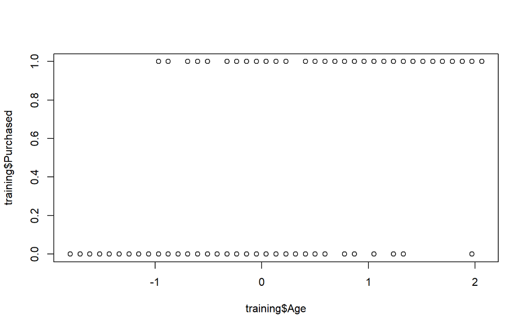

```r
plot(training$Age,training$Purchased)
```

```r
#curve(predict(model,data.frame(Age = x),type="response"),add=TRUE)
```

# Question 11

Now let us take another feature into account in the model. Fit a logistic regression model of `purchasing` the product in function of the `age` of the user and its `salary`.

```r
model2 = glm(Purchased~EstimatedSalary,family=binomial,data=training)
model2
```

```
##
## Call:  glm(formula = Purchased ~ EstimatedSalary, family = binomial,
##     data = training)
##
## Coefficients:
##     (Intercept)  EstimatedSalary
##         -0.6172           0.8528
##
## Degrees of Freedom: 239 Total (i.e. Null);  238 Residual
## Null Deviance:       315.4
## Residual Deviance: 280.4     AIC: 284.4
```

```r
summary(model2)
```

```
##
## Call:
## glm(formula = Purchased ~ EstimatedSalary, family = binomial,
##     data = training)
##
## Deviance Residuals:
##     Min       1Q   Median       3Q      Max
## -1.6145  -0.9330  -0.6822   0.9936   2.0177
##
## Coefficients:
##                 Estimate Std. Error z value Pr(>|z|)
## (Intercept)      -0.6172     0.1462  -4.222 2.42e-05 ***
## EstimatedSalary   0.8528     0.1571   5.428 5.71e-08 ***
## ---
## Signif. codes:  0 '***' 0.001 '**' 0.01 '*' 0.05 '.' 0.1 ' ' 1
##
## (Dispersion parameter for binomial family taken to be 1)
##
##     Null deviance: 315.44  on 239  degrees of freedom
## Residual deviance: 280.39  on 238  degrees of freedom
## AIC: 284.39
##
## Number of Fisher Scoring iterations: 4
```

# Question 12

Are the predictors significant? Did the model get better by adding the estimated salary?

```r
# Yes the predictor are significant but it didn't get better, the p-value increased
```

# Question 13

Did the model get better by adding t he estimated salary?

```r
# No p-value increased
```

# Question 14

On the test set, predict the probability of purchasing the product by the users using the obtained model

```r
model2_predict = predict(model2, testing, type = "response")
model2_predict
```

```
##         4         5         9        10        14        15        19        20
## 0.2890981 0.3934394 0.1839930 0.3311070 0.1349219 0.4291210 0.1662569 0.1696911
##        24        25        29        30        34        35        39        40
## 0.1468115 0.1499163 0.2237764 0.1349219 0.2280737 0.4778015 0.3702440 0.1767284
##        44        45        49        50        54        55        59        60
## 0.1265467 0.4412004 0.7343765 0.4716739 0.1499163 0.2941744 0.1349219 0.6398295
##        64        65        69        70        74        75        79        80
## 0.6566371 0.4351511 0.3203140 0.3476323 0.6168812 0.1349219 0.4594463 0.1320794
##        84        85        89        90        94        95        99       100
## 0.4655549 0.3149879 0.4231120 0.2550646 0.1662569 0.4351511 0.3759916 0.1992111
##       104       105       109       110       114       115       119       120
## 0.7959168 0.1437602 0.4533497 0.4171255 0.2791031 0.4171255 0.2993024 0.2993024
##       124       125       129       130       134       135       139       140
## 0.2693228 0.2597617 0.1320794 0.4412004 0.3476323 0.2791031 0.2993024 0.1562880
##       144       145       149       150       154       155       159       160
## 0.4716739 0.1562880 0.3097100 0.3817743 0.2550646 0.2413119 0.1731815 0.7343765
##       164       165       169       170       174       175       179       180
## 0.2031601 0.3532258 0.7918963 0.2413119 0.2237764 0.3702440 0.1499163 0.1877111
##       184       185       189       190       194       195       199       200
## 0.2237764 0.3044812 0.3702440 0.1803322 0.3588597 0.4716739 0.4171255 0.1468115
##       204       205       209       210       214       215       219       220
## 0.3645329 0.5452391 0.7665540 0.1468115 0.2941744 0.2237764 0.5146425 0.7709225
##       224       225       229       230       234       235       239       240
## 0.5513251 0.3044812 0.3702440 0.4171255 0.4533497 0.6110572 0.4291210 0.7709225
##       244       245       249       250       254       255       259       260
## 0.5634492 0.3702440 0.2645146 0.5207780 0.7836809 0.2280737 0.5085026 0.7147668
##       264       265       269       270       274       275       279       280
## 0.3702440 0.4778015 0.7752333 0.3097100 0.5754980 0.1595557 0.2031601 0.1953199
##       284       285       289       290       294       295       299       300
## 0.1437602 0.7621279 0.4111635 0.4052273 0.3993188 0.2890981 0.4111635 0.6398295
##       304       305       309       310       314       315       319       320
## 0.4111635 0.3044812 0.6837826 0.2550646 0.7621279 0.4111635 0.1803322 0.3044812
##       324       325       329       330       334       335       339       340
## 0.1731815 0.7147668 0.6454727 0.5814898 0.3311070 0.3044812 0.2791031 0.6676311
##       344       345       349       350       354       355       359       360
## 0.2597617 0.5694839 0.3993188 0.3097100 0.2890981 0.5330284 0.3645329 0.2741858
##       364       365       369       370       374       375       379       380
## 0.4111635 0.5634492 0.3645329 0.1595557 0.7097306 0.4171255 0.4594463 0.1499163
##       384       385       389       390       394       395       399       400
## 0.1662569 0.1839930 0.1877111 0.1914867 0.2195370 0.2993024 0.1839930 0.1953199
```

# Question 15

Take a look on your predicted values for the variable Purchased. We predicted the probability that the user will purchase the product right? Now in order to compare your results with the real answers, transform the predicted values to 0 or 1 (1 if >0.5).

```r
predict_value= ifelse(predict(model2,x = Purchased, type="response" )>0.5,1,0)
predict_value
```

```
##   1   2   3   6   7   8  11  12  13  16  17  18  21  22  23  26  27  28  31  32
##   0   0   0   0   0   1   0   0   0   0   0   0   0   0   0   0   0   0   0   1
##  33  36  37  38  41  42  43  46  47  48  51  52  53  56  57  58  61  62  63  66
##   0   0   0   0   0   0   1   0   0   0   0   0   0   0   0   0   0   0   0   0
##  67  68  71  72  73  76  77  78  81  82  83  86  87  88  91  92  93  96  97  98
##   0   0   0   0   0   1   0   0   0   0   0   1   0   0   0   1   0   0   0   1
## 101 102 103 106 107 108 111 112 113 116 117 118 121 122 123 126 127 128 131 132
##   0   0   0   0   0   0   0   0   0   0   0   0   0   0   0   0   0   0   0   0
## 133 136 137 138 141 142 143 146 147 148 151 152 153 156 157 158 161 162 163 166
##   0   0   0   1   0   0   0   0   1   0   0   0   0   0   0   0   1   0   0   0
## 167 168 171 172 173 176 177 178 181 182 183 186 187 188 191 192 193 196 197 198
##   0   0   0   1   1   0   0   0   0   0   1   0   0   0   0   0   0   0   0   0
## 201 202 203 206 207 208 211 212 213 216 217 218 221 222 223 226 227 228 231 232
##   0   0   1   0   1   1   1   1   0   1   0   0   0   0   1   0   1   1   1   0
## 233 236 237 238 241 242 243 246 247 248 251 252 253 256 257 258 261 262 263 266
##   1   0   0   0   1   0   0   1   0   1   0   0   1   0   0   0   0   1   1   1
## 267 268 271 272 273 276 277 278 281 282 283 286 287 288 291 292 293 296 297 298
##   0   0   1   0   0   0   0   0   0   0   0   0   0   1   1   0   0   0   0   1
## 301 302 303 306 307 308 311 312 313 316 317 318 321 322 323 326 327 328 331 332
##   0   0   1   0   1   1   0   1   0   0   1   0   1   0   0   0   0   0   0   1
## 333 336 337 338 341 342 343 346 347 348 351 352 353 356 357 358 361 362 363 366
##   0   0   1   0   1   0   0   0   0   1   1   0   0   0   0   0   1   0   0   0
## 367 368 371 372 373 376 377 378 381 382 383 386 387 388 391 392 393 396 397 398
##   0   0   0   0   0   0   0   0   0   0   1   0   0   0   0   0   0   0   0   0
```

# Question 16

Now to evaluate the predictions, compute the confusion matrix. What do you obtain ?

```r
#install.packages('caret')
conf_matrix = table(training$Purchased, predict_value>0.5)
conf_matrix
```

```
##
##     FALSE TRUE
##   0   145    7
##   1    47   41
```

# Question 17

Calculate the accuracy, specificity, sensitivity and the precision of the model

```r
#install.packages("caret")
#install.packages("ggplot2")
#library ('caret')
#sensitivity(conf_matrix)
#specificity(conf_matrix)
```

# Question 18

Plot the ROC curve and calculate AUC value

```r
#install.packages('Rtools')
#install.packages("verification")
#library(verification)

#roc.plot(model2,predict_value)
```

# Question 19

Compare the AUC of the two models you fitted (one with only age and one with age and estimated salary) and plot their ROC curves in the same figure.